# A4_Pollock_20151606

Caleb Pollock

2023-02-01

```r
library(ggplot2)
library(dplyr)
library(tidyr)
library(tree)
library(randomForest)
library(gbm)
source("https://bit.ly/theme_pub")
```

# Part 1 - Import Data and View Structure

```r
data <- read.csv("Cohen_CANCERSEEK_liquid_biopsy_2018_modified.csv")
```

```r
data$Tumor_type <- as.factor(data$Tumor_type) # Tumour is originally coded as a character, re-code as factor with 9 levels

head(data) # See top of data
```

```
##   Patient_ID     Sample_ID Tumor_type      AFP Angiopoietin_2     AXL CA_125
## 1    CRC 455 CRC 455 PLS 1 Colorectum 1583.450        5598.50 3621.04  5.090
## 2    CRC 456 CRC 456 PLS 1 Colorectum  715.308       20936.35 2772.96  7.270
## 3    CRC 457 CRC 457 PLS 1 Colorectum 4365.530        2350.93 4120.77  4.854
## 4    CRC 458 CRC 458 PLS 1 Colorectum  715.308        1604.34 2029.96  5.390
## 5    CRC 459 CRC 459 PLS 1 Colorectum  801.300        2087.57 2069.17  4.854
## 6    CRC 460 CRC 460 PLS 1 Colorectum  715.308        1147.55 2054.90  4.854
##   CA_15_3 CA19_9  CD44    CEA CYFRA_21_1 DKK1 Endoglin   FGF2 Follistatin
## 1   19.08 16.452  9.81  540.1   1938.654 0.78  2882.65  92.02     2144.33
## 2   10.04 40.910 27.57 5902.4   1938.654 0.77  3921.77 164.06     1646.26
## 3   16.96 16.452 14.59  973.8   1976.940 0.90  2410.16 154.77     2486.88
## 4    8.31 16.452  7.78 2027.5   1938.654 0.64  1284.96 227.57      829.43
## 5   11.73 16.452 12.21  614.5   1938.654 0.78  2552.72 134.72     2168.23
## 6    5.49 39.510  6.97 1242.3   1938.654 0.75  2459.50 123.75     1341.11
##   Galectin_3  G_CSF GDF15      HE4    HGF   IL_6   IL_8 Kallikrein_6    Leptin
```

[output cut: 27 more lines]

```r
str(data) # Observe data structure
```

```
## 'data.frame':    1804 obs. of  42 variables:
##  $ Patient_ID         : chr  "CRC 455" "CRC 456" "CRC 457" "CRC 458" ...
##  $ Sample_ID          : chr  "CRC 455 PLS 1" "CRC 456 PLS 1" "CRC 457 PLS 1" "CRC 458 PLS 1" ...
##  $ Tumor_type         : Factor w/ 9 levels "Breast","Colorectum",..: 2 2 2 2 2 2 2 2 2 2 ...
##  $ AFP                : num  1583 715 4366 715 801 ...
##  $ Angiopoietin_2     : num  5598 20936 2351 1604 2088 ...
##  $ AXL                : num  3621 2773 4121 2030 2069 ...
##  $ CA_125             : num  5.09 7.27 4.85 5.39 4.85 ...
##  $ CA_15_3            : num  19.08 10.04 16.96 8.31 11.73 ...
##  $ CA19_9             : num  16.5 40.9 16.5 16.5 16.5 ...
##  $ CD44               : num  9.81 27.57 14.59 7.78 12.21 ...
##  $ CEA                : num  540 5902 974 2028 614 ...
##  $ CYFRA_21_1         : num  1939 1939 1977 1939 1939 ...
##  $ DKK1               : num  0.78 0.77 0.9 0.64 0.78 0.75 0.86 0.71 0.59 0.64 ...
##  $ Endoglin           : num  2883 3922 2410 1285 2553 ...
```

[output cut: 28 more lines]

```r
colSums(is.na(data)) # Creates a table with the number of NA values for a given column -> AFP, Angiopoietin_2, AXL, CA_125, CA_15_3, CA19_9, CD44
```

```
##          Patient_ID           Sample_ID          Tumor_type                 AFP
##                   0                   0                   0                   1
##      Angiopoietin_2                 AXL              CA_125             CA_15_3
##                   1                   1                   1                   1
##              CA19_9                CD44                 CEA          CYFRA_21_1
##                   1                   1                   0                   0
##                DKK1            Endoglin                FGF2         Follistatin
##                   0                   0                   0                   0
##          Galectin_3               G_CSF               GDF15                 HE4
##                   0                   0                   0                   0
##                 HGF                IL_6                IL_8        Kallikrein_6
##                   0                   0                   0                   0
##              Leptin          Mesothelin             Midkine     Myeloperoxidase
##                   0                   0                   0                   0
##                 NSE                 OPG                 OPN                 PAR
##                   0                   0                   0                   0
##           Prolactin               sEGFR                sFas                SHBG
##                   0                   0                   0                   0
## sHER2_sEGFR2_sErbB2            sPECAM_1                TGFa    Thrombospondin_2
##                   0                   0                   0                   0
##              TIMP_1              TIMP_2
##                   0                   0
```

```r
data <- data %>% # Fix NA in data set
  mutate(AFP = ifelse(is.na(AFP),
                      mean(AFP, na.rm=T),AFP),
         Angiopoietin_2 = ifelse(is.na(Angiopoietin_2),
                                 mean(Angiopoietin_2, na.rm=T), Angiopoietin_2),
         AXL = ifelse(is.na(AXL),
                      mean(AXL, na.rm=T), AXL),
         CA_125 = ifelse(is.na(CA_125),
                         mean(CA_125, na.rm = T), CA_125),
         CA_15_3 = ifelse(is.na(CA_15_3),
                          mean(CA_15_3, na.rm=T), CA_15_3),
         CA19_9 = ifelse(is.na(CA19_9),
                         mean(CA19_9, na.rm = T), CA19_9),
         CD44 = ifelse(is.na(CD44),
                       mean(CD44, na.rm = T), CD44))

sum(is.na(data)) # Check and make sure all the NA are removed
```

```
## [1] 0
```

# Quality Control and Necessity of Normalizing Data

To preform quality control on the data set, I first used the structure function to get a preliminary look at the data. Immediately I noticed that Tumour_Type should be a factor, due to its nature of being a categorical variable. After that, I ran a function to determine the number of NAs in each column. After noticing that AFP, Angiopoietin_2, AXL, CA_125, CA_15_3, CA19_9 and CD44 contained NAs, I used the method in last weeks assignment to replace the NAs with the column mean.

It is not necessary to normalize the data for a Random Forest model due to the nature of the technique. Random Forest models are not sensitive to the scale of the data, and can handle variables coded in different units. The model builds so many different decision trees and picks the one with the the greatest accuracy, and scaling the variables can lead to over fitting.

# Dimensions of Final Data frame

```r
dim(data) # Shows the dimensions of the data
```

```
## [1] 1804   42
```

```r
table(data$Tumor_type) # Creates a table showing the number of cancer types
```

```
##
##     Breast Colorectum  Esophagus      Liver       Lung     Normal      Ovary
##        208        388         45         44        104        800         54
##   Pancreas    Stomach
##         93         68
```

# Number of Normal Samples and Tumour Samples

From the dimension of the data set, we can get the total number of cancer entries, which equals 1804. From the table of Tumour_Type, 800 normal samples are returned. Subtracting the number of normal samples by the total number of samples there are 1004 tumor samples, and 800 normal samples.

# Split Data set

```r
nrow <- nrow(data)
trainDat<-data[seq(1,nrow,by=2),] # Select only odds rows
Validate<-data[seq(2,nrow,by=2),] # Select only even rows

trainDat <- trainDat %>%
  select(-Patient_ID, -Sample_ID) # Only include the response and predictors
head(trainDat)
```

```
##    Tumor_type     AFP Angiopoietin_2     AXL CA_125 CA_15_3 CA19_9   CD44
## 1  Colorectum 1583.45        5598.50 3621.04  5.090   19.08 16.452  9.810
## 3  Colorectum 4365.53        2350.93 4120.77  4.854   16.96 16.452 14.590
## 5  Colorectum  801.30        2087.57 2069.17  4.854   11.73 16.452 12.210
## 7  Colorectum 1975.13        1900.89 3499.99  6.330   16.65 16.452 12.210
## 9  Colorectum 1039.85        1103.02  954.25  5.700    6.23 36.310  6.835
## 11 Colorectum  772.64        2371.75 4878.84  6.020    6.25 45.910 17.200
##        CEA CYFRA_21_1 DKK1 Endoglin   FGF2 Follistatin Galectin_3  G_CSF GDF15
## 1   540.10   1938.654 0.78  2882.65  92.02     2144.33      11.19 131.46  0.53
## 3   973.80   1976.940 0.90  2410.16 154.77     2486.88      11.61 131.46  0.50
## 5   614.50   1938.654 0.78  2552.72 134.72     2168.23       8.92 131.46  0.30
## 7   755.77   3329.430 0.86  1566.22 172.95     1765.41       7.67 422.75  0.28
## 9   895.66   1976.940 0.59  1513.17 205.52      790.19       5.63 131.46  0.14
## 11 2038.80   2129.610 0.69  1931.79  99.02     1291.93      14.62 131.46  0.44
##         HE4    HGF   IL_6    IL_8 Kallikrein_6    Leptin Mesothelin Midkine
```

[output cut: 27 more lines]

```r
Validate <- Validate %>%
  select(-Patient_ID, -Sample_ID) # Only include the response and predictors
head(Validate)
```

```
##    Tumor_type      AFP Angiopoietin_2     AXL CA_125 CA_15_3 CA19_9  CD44
## 2  Colorectum  715.308       20936.35 2772.96  7.270   10.04 40.910 27.57
## 4  Colorectum  715.308        1604.34 2029.96  5.390    8.31 16.452  7.78
## 6  Colorectum  715.308        1147.55 2054.90  4.854    5.49 39.510  6.97
## 8  Colorectum  992.170        1783.54 2478.39  4.854   11.44 16.452 11.23
## 10 Colorectum 6002.130        1942.35 1692.65  4.854    7.29 16.452 10.87
## 12 Colorectum  868.130        1198.96 2375.93  4.854   15.11 16.452 11.64
##        CEA CYFRA_21_1 DKK1 Endoglin   FGF2 Follistatin Galectin_3  G_CSF GDF15
## 2  5902.40   1938.654 0.77  3921.77 164.06     1646.26       9.90 131.46  2.39
## 4  2027.50   1938.654 0.64  1284.96 227.57      829.43       4.80 152.24  0.19
## 6  1242.30   1938.654 0.75  2459.50 123.75     1341.11       6.25 131.46  1.09
## 8   478.98   1938.654 0.71  1574.60 145.02     1484.83       8.25 131.46  0.42
## 10  818.81   1938.654 0.64  2392.78 177.27     1229.47      14.81 131.46  0.14
## 12  672.19   1938.654 0.81  2581.94 177.27     1831.13      10.06 131.46  0.33
##         HE4    HGF   IL_6   IL_8 Kallikrein_6    Leptin Mesothelin Midkine
```

[output cut: 27 more lines]

# Part 2 - Decision Tree

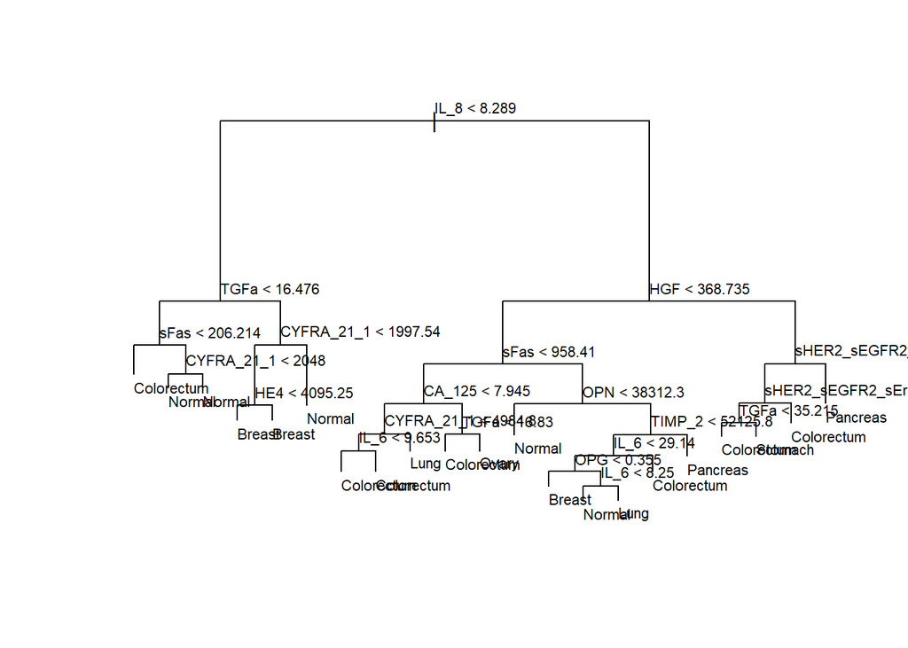

```r
trainMod <- tree(Tumor_type ~ ., data = trainDat) # Create the model based on the training data
plot(trainMod) # Plot the model
text(trainMod, cex = 0.70, adj = 0) # Add text to model
```

```r
summary(trainMod) # Summarize the model and provide performance metrics
```

```
##
## Classification tree:
## tree(formula = Tumor_type ~ ., data = trainDat)
## Variables actually used in tree construction:
##  [1] "IL_8"                "TGFa"                "sFas"
##  [4] "CYFRA_21_1"          "HE4"                 "HGF"
##  [7] "CA_125"              "IL_6"                "OPN"
## [10] "TIMP_2"              "OPG"                 "sHER2_sEGFR2_sErbB2"
## Number of terminal nodes:  21
## Residual mean deviance:  1.638 = 1443 / 881
## Misclassification error rate: 0.2993 = 270 / 902
```

# Most Influential Protein Feature

Observing the figure produced above, it is likely that IL_8 is the most important feature in classifying samples. This is because it is the first feature as part of the decision tree and it contains the longest branch length.

# Confusion Matrix

```r
CatDat <- data.frame(Obs = trainDat$Tumor_type, Pred = predict(trainMod, Validate, type = 'class')) # Create a confusion matrix of obs and predicted values
table(CatDat)
```

```
##             Pred
## Obs          Breast Colorectum Esophagus Liver Lung Normal Ovary Pancreas
##   Breast         27         43         0     0   12     14     2        6
##   Colorectum     22         92         0     0   22     33     5        4
##   Esophagus       7         11         0     0    1      3     0        0
##   Liver           4          8         0     0    2      2     1        0
##   Lung            6         21         0     0   16      8     2        2
##   Normal         10         39         0     0    0    342     1        8
##   Ovary           3          9         0     0    0      5     9        0
##   Pancreas        2          6         0     0    4      8     1       24
##   Stomach         2         14         0     0    2      1     2        2
##             Pred
## Obs          Stomach
##   Breast           2
##   Colorectum      13
##   Esophagus        4
##   Liver            3
##   Lung             0
##   Normal           0
##   Ovary            0
##   Pancreas         0
##   Stomach         10
```

```r
Correct <- CatDat %>% # Calculate the correct classifications
  filter(Obs==Pred)
nrow(Correct) / nrow(CatDat)
```

```
## [1] 0.5764967
```

```r
MisClass <- CatDat %>% # Calculate the mis-classified
  filter(Obs!=Pred)
nrow(MisClass) / nrow(CatDat)
```

```
## [1] 0.4235033
```

# Misclassification Rate

# Cancer Classification Rate

Analyzing the confusion matrix, it appears the decision tree was able to classify normal, colorectum, breast, pancreas, lung, stomach and ovary samples. It appeared to struggle with Esophagus and Liver cancer samples.

# Part 3 - Random Forest

```r
forMod <- randomForest(Tumor_type ~ ., data = trainDat, # Create the random forest
                       ntree = 100, mtry = 3, nodesize = 5, importance = TRUE)

forCatDat <- data.frame(Obs = trainDat$Tumor_type, Pred = predict(forMod, Validate, type = 'class')) # Create a confusion matrix of obs and predicted values
table(forCatDat)
```

```
##             Pred
## Obs          Breast Colorectum Esophagus Liver Lung Normal Ovary Pancreas
##   Breast         26         56         1     0    7     14     1        1
##   Colorectum     28        133         1     0    4     19     0        3
##   Esophagus       5         16         0     0    0      5     0        0
##   Liver           1         16         0     0    1      1     1        0
##   Lung           13         32         0     0    5      5     0        0
##   Normal          1          2         0     0    0    396     0        1
##   Ovary           0          5         0     0    1      4    16        0
##   Pancreas        2          8         0     0    1     16     1       17
##   Stomach         2         20         1     0    0      1     0        2
##             Pred
## Obs          Stomach
##   Breast           0
##   Colorectum       3
##   Esophagus        0
##   Liver            0
##   Lung             0
##   Normal           0
##   Ovary            0
##   Pancreas         0
##   Stomach          7
```

```r
Correct <- forCatDat %>% # Calculate the correct classifications
  filter(Obs==Pred)
nrow(Correct) / nrow(CatDat)
```

```
## [1] 0.6651885
```

```r
MisClass <- forCatDat %>% # Calculate the mis-classified
  filter(Obs!=Pred)
nrow(MisClass) / nrow(CatDat)
```

```
## [1] 0.3348115
```

# Random Forest Misclassification Rate

# Significance Plot

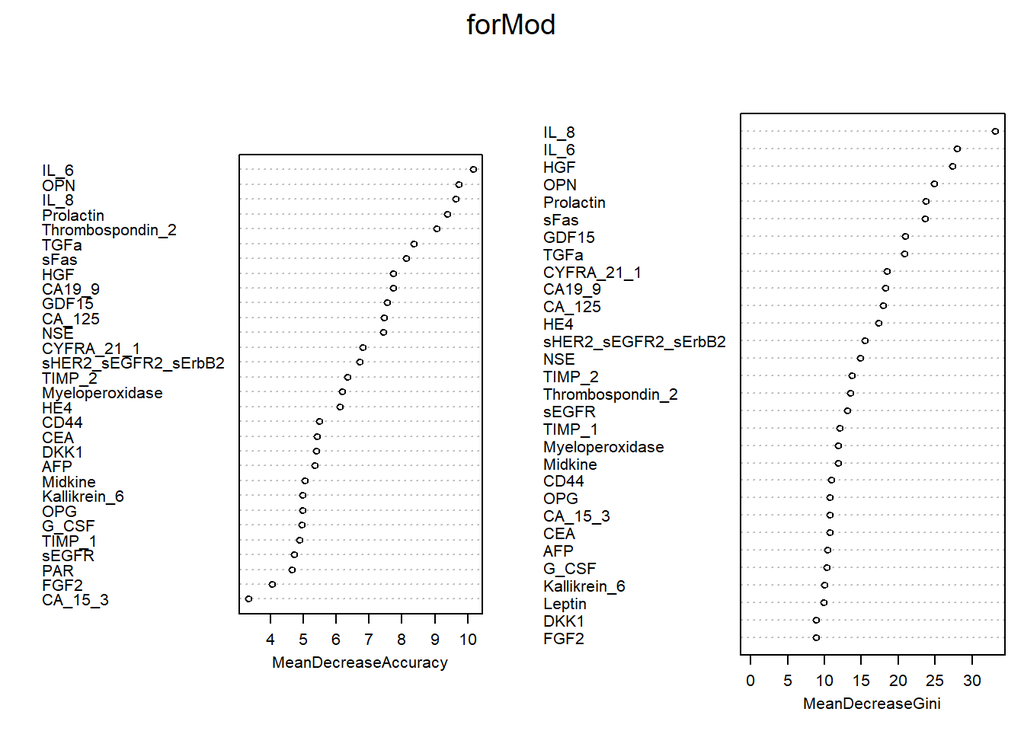

```r
varImpPlot(forMod, cex = 0.65)
```

From these plots, it appears that IL-8 is still the most important feature in classifying the different samples. The next important feature is IL-6.

# Combine all tumour types

```r
binDat <- data
binDat$binary <- ifelse(binDat$Tumor_type %in% c("Breast", "Colorectum", "Esophagus", "Liver", "Lung", "Ovary", "Pancreas", "Stomach"), "Cancer", "Normal") # Creates the binary data column of cancer or normal
binDat$binary <- as.factor(binDat$binary) # Codes as factor

binDat <- binDat %>%
  select(-Patient_ID, -Sample_ID, -Tumor_type)

nrow <- nrow(binDat)
binTrain<-binDat[seq(1,nrow,by=2),] # Select only odds rows
binValidate<-binDat[seq(2,nrow,by=2),] # Select only even rows
```

# Binary Random Forest

```r
binForMod <- randomForest(binary ~ ., data = binTrain, # Create the random forest
                       ntree = 100, mtry = 3, nodesize = 5, importance = TRUE)

binForMod
```

```
##
## Call:
##  randomForest(formula = binary ~ ., data = binTrain, ntree = 100,      mtry = 3, nodesize = 5, importance = TRUE)
##                Type of random forest: classification
##                      Number of trees: 100
## No. of variables tried at each split: 3
##
##         OOB estimate of  error rate: 6.21%
## Confusion matrix:
##        Cancer Normal class.error
## Cancer    487     15  0.02988048
## Normal     41    359  0.10250000
```

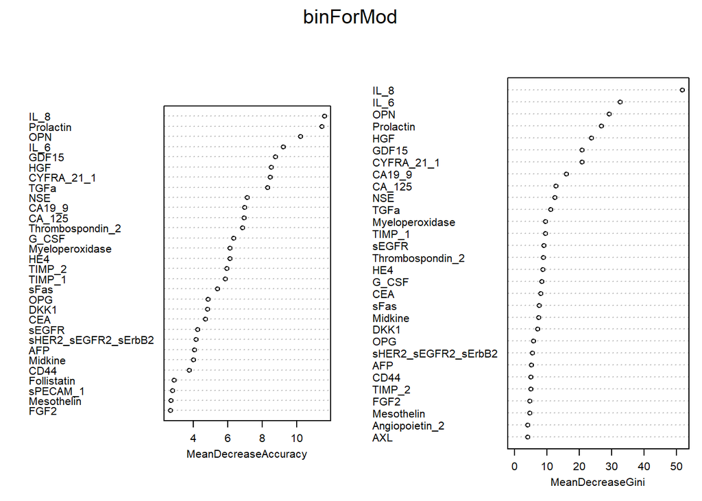

```r
varImpPlot(binForMod, cex = 0.65)
```

# Protein Features for Binary Model

The binary cancer or normal sample model shows that IL_8 and IL_6 are the most important features for classifying blood samples as being cancerous or non cancerous.

This may be due to the fact that IL_8 and IL_6 are both interleukin immune proteins, which are produced during an immune response. It would make sense that the blood samples containing components of an immune response characterizes samples as cancerous or not, as immune cells will be actively engaged with fighting cancer. This means that samples which contain cancer are more likely to contain immune proteins which act to fight the cancer.